# Initial ExPeCT Data Analysis, Subjective Focus

Bryan Stanfill  
December 20, 2017

### Questionnaire & Exercise Perspective Goals

- To determine changes in lifestyle questionnaires at three time points
  - Stress
  - Depression
  - Sleep
  - Quality of Life
- Compare the results of questionnaires between exercise and non-exercise participants at three time points
- To determine the impact of patients' adherence to the exercise program on lifestyle questionnaires

### Notes

- Some participants have complete questionnaire results but were marked as EXCLUDED in the CTC master file (Exp023, G-011, G-018 and G-032). I excluded those participants from the following analysis.

### Adherence to PA Guidelines

- I used the reported overall MET hours per week to measure adherence to PA guidelines
- Two people in the Irish group have a large impact on the model results

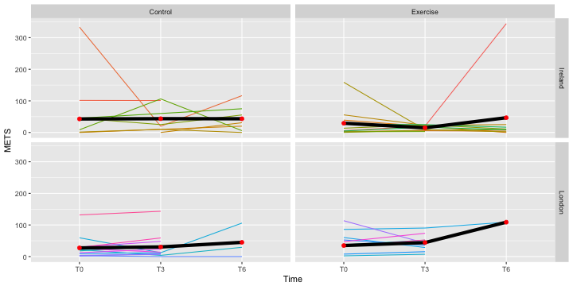

### Adherence to PA Guidelines, Cont'd

- I removed those individuals and fit the model again
- With them removed, there is a borderline significant difference between the exercise group in London versus the other groups, though that's likely due to the small sample size in the T6, London, Exercise group

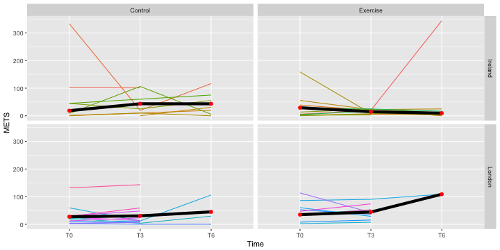

### Analysis for Other Questions

- Subjective questionnaires are difficult to analyze because of differences between individuals' baseline (a “7” to me may be your “5”)
- Instead of analyzing the raw scores, I analyzed changes in scores between consecutive time points
- To increase statistical power, changes in scores were categorized into increases, decreases and no change. A drawback of this is that the magnitude of the change is lost
- I used multinomial logistic regression to estimate the probability of each type of change by location, group and time point

### Stress Analysis

- The bubbles represent the probability of each outcome, the color indicates which outcome is most likely
- A positive T0:T3 values means the reported stress score increased from time point T0 to time point T3

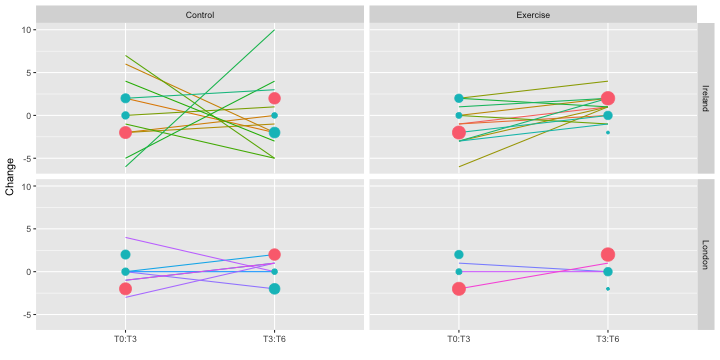

### Depression Analysis

- The bubbles represent the probability of each outcome, the color indicates which outcome is most likely
- A positive T0:T3 values means the reported depression score increased from time point T0 to time point T3

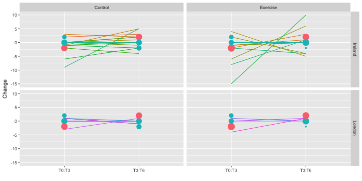

### Sleep Analysis

- The bubbles represent the probability of each outcome, the color indicates which outcome is most likely
- A positive T0:T3 values means the reported sleep score increased from time point T0 to time point T3

[figure not shown]

### Overall Quality of Life Analysis

- The bubbles represent the probability of each outcome, the color indicates which outcome is most likely
- A positive T0:T3 values means the overall QOL score increased from time point T0 to time point T3

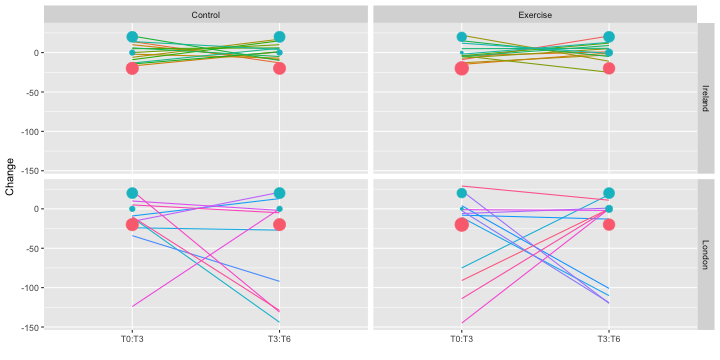